# Data Preprocessing and Visualization

Or how to get the first insights from raw data

Statistical Learning, Bachelor in Data Science and Engineering

UC3M, 2021

## Introduction

Data processing, and in particular, feature engineering is the process of generating features (variables) useful as input for machine-learning tools. The better the input, the better the prediction.

> Coming up with features is difficult, time-consuming, requires expert knowledge. ‘Applied machine learning’ is basically feature engineering — Prof. Andrew Ng.

**Data-science steps:**

1. Prepare the input: collect, clean, transform, filter, aggregate, merge, verify, etc.
2. Prepare a model: build, estimate, validate, predict, etc.
3. Prepare the output: communicate the results, interpret, publish, etc.

Feature engineering focuses on the first step, with emphasis in getting information: collect, clean, transform, filter, aggregate, merge, verify, etc.

Half of the success of a machine-learning project is the features used. The other 50% is the model.

> Feature engineering is the process of transforming raw data into features that better represent the underlying problem to the predictive models, resulting in improved model accuracy on unseen data. — Dr. Jason Brownlee

## What’s a feature?

A feature is a specific representation on top of raw data: a measurable attribure or variable, typically a column in a dataset.

Basically two types:

1. Raw features: obtained directly from the dataset with no extra data manipulation or engineering.
2. Derived features: usually obtained from feature extraction (from other data attributes).

## Data cleaning

- Remove duplicate or irrelevant observations
- Fix or remove typos or errors
- Outliers
- Missing values

## Feature extraction

- Get features from many data sources.
- Smooth (filter) some variables: for instance, getting monthly information from hourly data. Or getting municipality information from census data.
- Discretization of variables: for instance, creating two groups (Young and Old) from age data to reduce nose. Or encoding the month of the year.
- Normalization: unify the units of our variables (scale or standardization).
- Combination of variables: for instance, density of population (from inhabitants and area). Or PCA for more complex datasets
- Variable selection: how to select the most *promising* variables from the available dozens or hundreds ones.
- Most advanced tool nowadays: **deep learning** can build features through the hidden layers (deep), specially useful for images, text, video, etc.

## Today’s session

**Objective:** practice with feature extraction and data cleaning to learn about some socio-economic variables in Spain. In particular, we are going to learn about the causes of election participation, unemployment rates, etc.

Organization:

1. Get variables from many sources
2. Obtain information through feature engineering
3. Make cool graphs
4. Deal with outliers and missings

We will use R, hence start by loading some packages:

```r
library(tidyverse)
library(leaflet)
library(rgdal)
library(stringr)
library(htmltab)
```

## First data source

From Ministerio del Interior (Spain), we have data at very low level (poll station) about elections.

In particular, this part of the analysis is based on Esteban Moro’s script to build the map of participation by census area: https://github.com/emoro/master201819/blob/master/01_Mapa_participacion_2016.Rmd

which is similar to the one created by Kiko Llaneras and Nacho Carretero in this article https://elpais.com/politica/2019/03/28/actualidad/1553783809_455746.html

Download first data from [Ministerio del Interior](http://www.infoelectoral.mir.es/infoelectoral/min/areaDescarga.html) (last available elections: Nov 2019)

```r
url = "http://www.infoelectoral.mir.es/infoelectoral/docxl/apliextr/02201911_MESA.zip"

temp <- tempfile()
download.file(url,dest="data/MESA.zip")
unzip("data/MESA.zip", exdir = "data/")
```

We will use the file “09021911.DAT” that contains information about participation by poll station. See “Ficheros.doc” for more details.

Read now data file and assign names

```r
participacion <- read.fwf("data/09021911.DAT",
                          widths=c(2,4,2,1,
                                   2,2,3,2,4,1,
                                   7,7,7,7,7,7,7,7,7,7,7,
                                   1),
                          colClasses=c(rep("numeric",4),
                                       rep("character",6),
                                       rep("numeric",11),
                                       "character"))

colnames(participacion) <- c("tipo","year","month","vuelta","ccaa","provincia","municipio","distrito","seccion","mesa","censo","censo_escrutinio","censo_cere","total_cere","votantes_primer","votantes_segundo","blanco","nulos","votos","afirmativos","negativos","datos_oficiales")
```

Take a look

```r
head(participacion)
```

```
##   tipo year month vuelta ccaa provincia municipio distrito seccion mesa censo
## 1    2 2019    11      1   01        04       003       02    001     B   446
## 2    2 2019    11      1   01        04       006       02    001     A   842
## 3    2 2019    11      1   01        04       006       04    001     B   454
## 4    2 2019    11      1   01        04       013       03    008     U   662
## 5    2 2019    11      1   01        04       013       04    006     U   666
## 6    2 2019    11      1   01        04       013       06    006     A   925
##   censo_escrutinio censo_cere total_cere votantes_primer votantes_segundo
## 1              446          0          0             141              215
## 2              842          0          0             280              440
## 3              454          0          0             133              216
## 4              662          0          0             194              255
## 5              666          0          0             305              400
## 6              925          0          0             240              360
##   blanco nulos votos afirmativos negativos datos_oficiales
## 1      1     0   270           0         0               S
## 2      4     8   533           0         0               S
## 3      3     2   264           0         0               S
## 4      1     2   290           0         0               S
## 5      2     7   481           0         0               S
## 6      5     2   461           0         0               S
```

This is high granularity data: information up to *mesa electoral*

We will base our analysis to: ccaa, provincia, municipio, censo, votos

```r
participacion = participacion %>% select(ccaa, provincia, municipio, censo, votos)
```

Now we are ready to start with our **feature engineering**:

**Filter out** some noisy information

We will focus on national elections

```r
participacion = participacion %>% filter(ccaa<99, provincia<99, municipio<999)
```

**Feature extraction**

First, build participation level (from votos and censo). Then build the CODIGOINE identification for municipality, which we use later as the variable to merge more datasets.

```r
participacion = participacion %>% mutate(part=votos/censo,
                                         CODIGOINE = str_trim(paste0(participacion$provincia,participacion$municipio)))
```

Take a look:

```r
str(participacion)
```

```
## 'data.frame':    59555 obs. of  7 variables:
##  $ ccaa     : chr  "01" "01" "01" "01" ...
##  $ provincia: chr  "04" "04" "04" "04" ...
##  $ municipio: chr  "003" "006" "006" "013" ...
##  $ censo    : num  446 842 454 662 666 925 567 740 605 661 ...
##  $ votos    : num  270 533 264 290 481 461 336 459 356 447 ...
##  $ part     : num  0.605 0.633 0.581 0.438 0.722 ...
##  $ CODIGOINE: chr  "04003" "04006" "04006" "04013" ...
```

```r
head(participacion)
```

```
##   ccaa provincia municipio censo votos      part CODIGOINE
## 1   01        04       003   446   270 0.6053812     04003
## 2   01        04       006   842   533 0.6330166     04006
## 3   01        04       006   454   264 0.5814978     04006
## 4   01        04       013   662   290 0.4380665     04013
## 5   01        04       013   666   481 0.7222222     04013
## 6   01        04       013   925   461 0.4983784     04013
```

Nicer!

Note there are close to 60000 poll stations, 17 CCAA, 52 provinces, and more than 8000 municipalities

Convert char variables into factor ones: this conversion will be used in R models as encoding (creation of dummies)

```r
participacion$ccaa = as.factor(participacion$ccaa)
participacion$provincia = as.factor(participacion$provincia)
participacion$CODIGOINE = as.factor(participacion$CODIGOINE)
```

Just a break to understand how participation is explained by granularity

```r
summary(lm(part ~ ccaa, participacion))$adj.r.squared
```

```
## [1] 0.218355
```

```r
summary(lm(part ~ provincia, participacion))$adj.r.squared
```

```
## [1] 0.2581408
```

```r
# the next model takes a while
# summary(lm(part ~ CODIGOINE, participacion))$adj.r.squared
```

Let’s continue. High noise because the high granularity. Some CCAA with censo<=10, or censo>=1000:

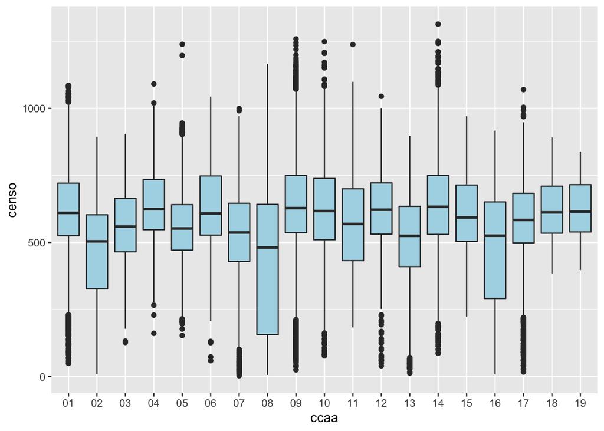

```r
participacion %>% ggplot(aes(x=ccaa,y=censo)) + geom_boxplot(fill="lightblue")
```

**Aggregation:**

We will use information at municipality level, hence we are going to aggregate results to that level.

We will reduce noise (variability) at the price of losing also some information:

```r
part.aggr <- participacion %>%
  group_by(ccaa,provincia,municipio,CODIGOINE) %>%
  summarize(total_votos=sum(votos),total_censo=sum(censo)) %>%
  mutate(total_part = total_votos/total_censo)
```

Take a look:

```r
head(part.aggr)
```

```
## # A tibble: 6 x 7
## # Groups:   ccaa, provincia, municipio [6]
##   ccaa  provincia municipio CODIGOINE total_votos total_censo total_part
##   <fct> <fct>     <chr>     <fct>           <dbl>       <dbl>      <dbl>
## 1 01    04        001       04001             707        1002      0.706
## 2 01    04        002       04002             698        1013      0.689
## 3 01    04        003       04003           10864       17583      0.618
## 4 01    04        004       04004             270         405      0.667
## 5 01    04        005       04005             416         534      0.779
## 6 01    04        006       04006            4296        7192      0.597
```

Participation by provincia

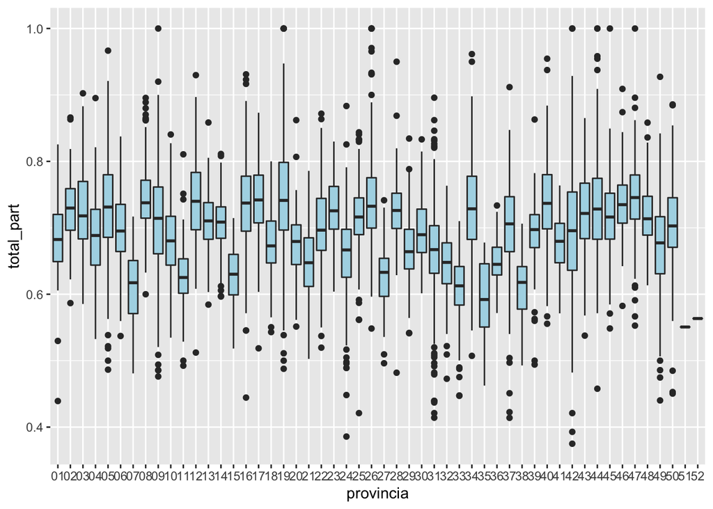

```r
part.aggr %>% ggplot(aes(x=provincia,y=total_part)) + geom_boxplot(fill="lightblue")
```

Boxplots are very useful to identify differences in provincias.

**Outliers:**

Outliers are atypical/extreme values that are far from the rest of the values

One of the most useful tools to identify outliers is the boxplot: for instance, municipalities with participation=100%, or less than 40%.

This is called *univariate identification*. There are other useful univariate tools:

Identification by the *3-sigma rule*:

```r
mu <- mean(part.aggr$total_part)
sigma <- sd(part.aggr$total_part)

sum(part.aggr$total_part < mu - 3*sigma | part.aggr$total_part > mu + 3*sigma)
```

```
## [1] 79
```

Identification by *IQR*:

```r
QI <- quantile(part.aggr$total_part, 0.25)
QS <- quantile(part.aggr$total_part, 0.75)
IQR = QS-QI

sum(part.aggr$total_part < QI - 1.5*IQR | part.aggr$total_part > QS + 1.5*IQR)
```

```
## [1] 199
```

Depending on the context we must decide what to do:

- Remove them:
  - Can a municipality have a participation greater than 100% or smaller than 0%?
- Leave them:
  - Can a municipality have a participation smaller than 40%?

**Can we create more variables?**

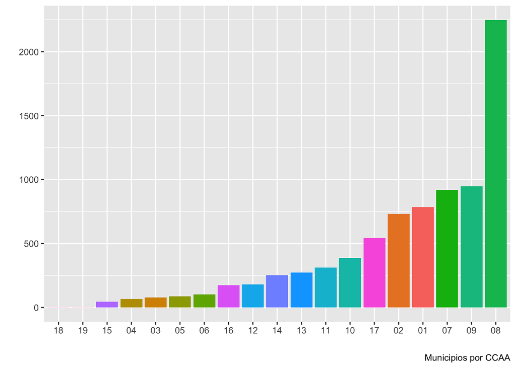

```r
# municipalities by ccaa
part.aggr %>% ggplot(aes(x=reorder(ccaa, ccaa, length))) +geom_bar(aes(fill=ccaa)) +
  labs(caption="Municipios por CCAA",
       x = "", y = "")+ theme(legend.position="none")
```

We just need imagination…

Also note we still do not have the names for provinces, ccaa, etc.

## Second data source

To explain participation level, besides provincia or municipality, we need more variables like the unemployment rate, or the population age, or the income for each municipality.

Let’s start by downloading the unemployment rate in Spain by municipality.

Source: [Datos Abiertos Gobierno de España](https://datos.gob.es)

```r
url = "https://sede.sepe.gob.es/es/portaltrabaja/resources/sede/datos_abiertos/datos/Paro_por_municipios_2019_csv.csv"
paro = read.csv2(url, skip=1, header=T, sep=";", encoding="latin1")
#paro = read.csv2("data/Paro_por_municipios_2019_csv.csv", skip=1, header=T, sep=";", encoding="latin1")
```

Take a look:

```r
str(paro)
```

```
## 'data.frame':    97524 obs. of  20 variables:
##  $ Código.mes              : int  201901 201901 201901 201901 201901 201901 201901 201901 201901 201901 ...
##  $ mes                     : chr  "Enero de 2019" "Enero de 2019" "Enero de 2019" "Enero de 2019" ...
##  $ Código.de.CA            : int  1 1 1 1 1 1 1 1 1 1 ...
##  $ Comunidad.Autónoma      : chr  "Andalucía" "Andalucía" "Andalucía" "Andalucía" ...
##  $ Codigo.Provincia        : int  4 4 4 4 4 4 4 4 4 4 ...
##  $ Provincia               : chr  "Almería" "Almería" "Almería" "Almería" ...
##  $ Codigo.Municipio        : int  4001 4002 4003 4004 4005 4006 4007 4008 4009 4010 ...
##  $ Municipio               : chr  "Abla" "Abrucena" "Adra" "Albánchez" ...
##  $ total.Paro.Registrado   : int  77 62 2088 18 35 755 66 19 3 88 ...
##  $ Paro.hombre.edad...25   : int  4 5 103 0 1 30 2 1 1 5 ...
##  $ Paro.hombre.edad.25..45 : int  15 9 385 2 8 126 8 1 1 18 ...
##  $ Paro.hombre.edad...45   : int  23 14 449 6 12 158 30 9 0 31 ...
##  $ Paro.mujer.edad...25    : int  4 5 97 1 1 28 2 1 0 1 ...
##  $ Paro.mujer.edad.25..45  : int  21 16 569 7 8 244 15 4 0 19 ...
##  $ Paro.mujer.edad...45    : int  10 13 485 2 5 169 9 3 1 14 ...
##  $ Paro.Agricultura        : int  11 7 386 1 4 60 11 1 0 2 ...
##  $ Paro.Industria          : int  5 6 73 0 4 43 1 1 0 17 ...
##  $ Paro.Construcción       : int  5 9 250 2 7 82 11 5 0 29 ...
##  $ Paro.Servicios          : int  52 36 1174 15 19 517 42 11 3 31 ...
##  $ Paro.Sin.empleo.Anterior: int  4 4 205 0 1 53 1 1 0 9 ...
```

```r
head(paro)
```

```
##   Código.mes           mes Código.de.CA Comunidad.Autónoma Codigo.Provincia
## 1     201901 Enero de 2019            1          Andalucía                4
## 2     201901 Enero de 2019            1          Andalucía                4
## 3     201901 Enero de 2019            1          Andalucía                4
## 4     201901 Enero de 2019            1          Andalucía                4
## 5     201901 Enero de 2019            1          Andalucía                4
## 6     201901 Enero de 2019            1          Andalucía                4
##   Provincia Codigo.Municipio Municipio total.Paro.Registrado
## 1   Almería             4001      Abla                    77
## 2   Almería             4002  Abrucena                    62
## 3   Almería             4003      Adra                  2088
## 4   Almería             4004 Albánchez                    18
## 5   Almería             4005 Alboloduy                    35
## 6   Almería             4006     Albox                   755
##   Paro.hombre.edad...25 Paro.hombre.edad.25..45 Paro.hombre.edad...45
```

[output cut: 27 more lines]

Here we have a lot of information!

Select relevant variables and filter out the month (we are just interested in 2019 year): **aggregation**

```r
paro = paro %>% select(c(1,4,6,7,8,9))
colnames(paro) = c("Mes", "CCAA", "Provincia", "CODIGOINE", "Municipio", "Paro")

paro$Mes = as.factor(paro$Mes)
paro.aggr <- paro %>%
  group_by(CCAA, Provincia, Municipio, CODIGOINE) %>%
  summarize(total_paro=mean(Paro))
```

Note we have used the same name for CODIGOINE. This will allow as to join the data sets

**Merge**

```r
# CODIGOINE must be in the same format (char) and with same numbers
paro.aggr$CODIGOINE=factor(str_pad(paro.aggr$CODIGOINE, 5, pad = "0"))
total.data=merge(part.aggr, paro.aggr, by="CODIGOINE", all.x=T)
```

Take care: there are 32 missing values:

```r
sum(is.na(total.data))
```

```
## [1] 32
```

**Missing values**

A missing value is a non-present vaule in a variable

Most of the real datasets have missing values. We need to identify them and decide what to do

They are usually represented by NULL or NA, but sometimes the are given by specific codes (for instance 9999)

Distribution of NAs using mice package

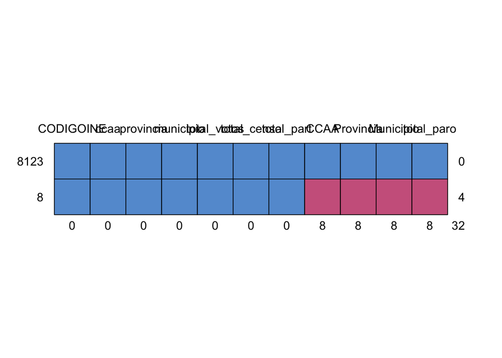

```
##      CODIGOINE ccaa provincia municipio total_votos total_censo total_part CCAA
## 8123         1    1         1         1           1           1          1    1
## 8            1    1         1         1           1           1          1    0
##              0    0         0         0           0           0          0    8
##      Provincia Municipio total_paro
## 8123         1         1          1  0
## 8            0         0          0  4
##              8         8          8 32
```

```r
library(mice)
md.pattern(total.data)
```

There are 8 municipalities with missing values. They are in the 4 paro variables

What to do?

- If they are just a few and not relevant, we can delete them. Say less than 5% of the sample
- Otherwise:
  - We can remove rows when most of their corresponding variables are empty
  - We can remove columns when most of their corresponding rows are empty
  - In other cases, we can impute NAs:
    - Simple imputation (use the mean for non-NAs, or the median, mode, etc.)
    - Regressions: train with non-NAs to predict NAs
    - k-nearest neighbour (kNN) imputation
    - Multiple imputation: for each NA, multiple imputations are found to capture better sample variability, and then a pooling approach is performed to have the final imputation

Because we only have a few NAs, let’s remove them (8 rows):

```r
total.data <- na.omit(total.data)
```

Later we will see more advanced approaches

Now we have the names for CCAA, Provincia, and Municipio

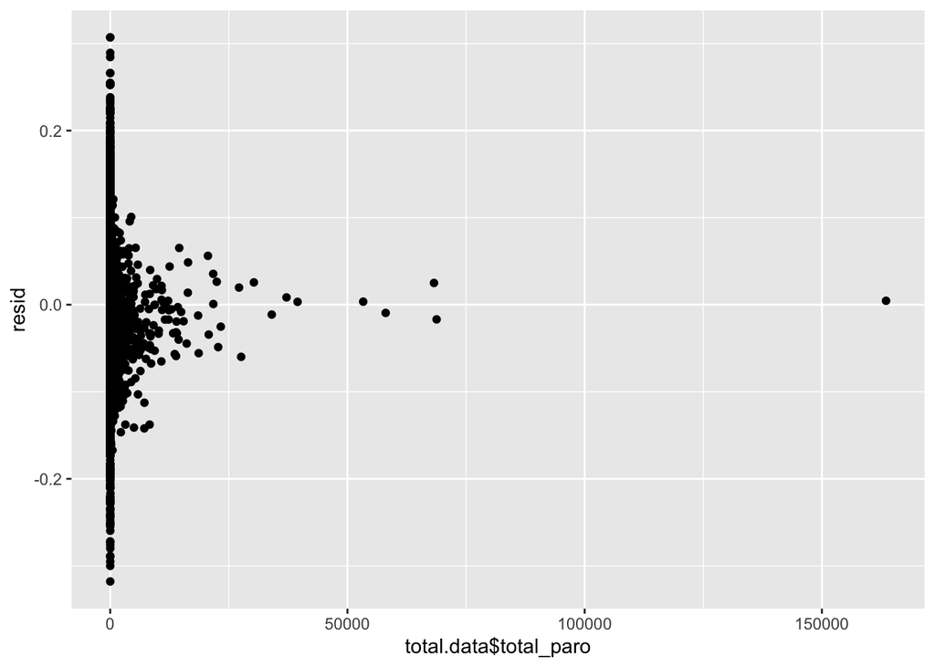

```r
lm.fit = lm(total_part ~ provincia, total.data)
resid = residuals(lm.fit)
qplot(total.data$total_paro, resid)
```

```r
summary(lm(total_part ~ provincia + total_paro, total.data))
```

```
##
## Call:
## lm(formula = total_part ~ provincia + total_paro, data = total.data)
##
## Residuals:
##      Min       1Q   Median       3Q      Max
## -0.31790 -0.03663 -0.00070  0.03748  0.30710
##
## Coefficients:
##               Estimate Std. Error t value Pr(>|t|)
## (Intercept)  6.796e-01  8.968e-03  75.776  < 2e-16 ***
## provincia02  4.507e-02  1.129e-02   3.991 6.65e-05 ***
## provincia03  4.862e-02  1.047e-02   4.646 3.45e-06 ***
## provincia04  1.266e-02  1.097e-02   1.155 0.248224
## provincia05  4.885e-02  9.847e-03   4.961 7.15e-07 ***
## provincia06  1.858e-02  1.026e-02   1.811 0.070255 .
## provincia07 -7.014e-02  1.190e-02  -5.894 3.93e-09 ***
## provincia08  6.439e-02  9.676e-03   6.654 3.03e-11 ***
## provincia09  3.119e-02  9.564e-03   3.261 0.001115 **
## provincia10  1.529e-03  9.940e-03   0.154 0.877764
## provincia11 -4.701e-02  1.320e-02  -3.562 0.000371 ***
## provincia12  6.065e-02  1.053e-02   5.762 8.61e-09 ***
## provincia13  3.430e-02  1.098e-02   3.123 0.001798 **
## provincia14  2.762e-02  1.162e-02   2.376 0.017521 *
## provincia15 -5.140e-02  1.116e-02  -4.606 4.16e-06 ***
## provincia16  5.432e-02  9.882e-03   5.497 3.99e-08 ***
## provincia17  6.172e-02  9.949e-03   6.204 5.78e-10 ***
## provincia18  2.509e-04  1.021e-02   0.025 0.980393
## provincia19  6.794e-02  9.730e-03   6.982 3.13e-12 ***
## provincia20 -4.875e-03  1.127e-02  -0.433 0.665335
## provincia21 -2.999e-02  1.150e-02  -2.607 0.009156 **
## provincia22  2.329e-02  1.004e-02   2.320 0.020346 *
## provincia23  4.963e-02  1.108e-02   4.481 7.55e-06 ***
## provincia24 -2.098e-02  9.993e-03  -2.100 0.035768 *
## provincia25  3.652e-02  9.908e-03   3.686 0.000230 ***
## provincia26  6.645e-02  1.020e-02   6.517 7.63e-11 ***
## provincia27 -5.197e-02  1.190e-02  -4.367 1.28e-05 ***
## provincia28  4.701e-02  1.017e-02   4.621 3.88e-06 ***
## provincia29 -1.003e-02  1.097e-02  -0.914 0.360650
## provincia30  1.638e-02  1.311e-02   1.250 0.211348
```

[output cut: 14 more lines]

```
## provincia45  3.625e-02  1.003e-02   3.616 0.000301 ***
## provincia46  5.788e-02  9.790e-03   5.912 3.51e-09 ***
## provincia47  6.569e-02  9.932e-03   6.614 3.98e-11 ***
## provincia48  3.937e-02  1.082e-02   3.640 0.000275 ***
## provincia49 -5.487e-03  9.847e-03  -0.557 0.577405
## provincia50  2.553e-02  9.717e-03   2.627 0.008631 **
## provincia51 -1.204e-01  6.473e-02  -1.860 0.062882 .
## provincia52 -1.093e-01  6.471e-02  -1.689 0.091344 .
## total_paro  -7.281e-07  2.628e-07  -2.770 0.005614 **
## ---
## Signif. codes:  0 '***' 0.001 '**' 0.01 '*' 0.05 '.' 0.1 ' ' 1
##
## Residual standard error: 0.06404 on 8070 degrees of freedom
## Multiple R-squared:  0.2293, Adjusted R-squared:  0.2243
## F-statistic: 46.16 on 52 and 8070 DF,  p-value: < 2.2e-16
```

Paro is not informative: it is in absolute values (not relative), hence it is related to population mainly

We need total population by municipality in order to create Paro in percentage

## Third data source

```r
municipios.moredata = read.csv(url("http://www.est.uc3m.es/nogales/municipios2017.csv"), header=T, sep=",")
# municipios.moredata = read.csv("data/municipios2017.csv", header=T, sep=",")
head(municipios.moredata)
```

```
##   CODIGOINE SUPERFICIE ALTITUD LONGITUD_ETRS89 LATITUD_ETRS89 EDAD_MEDIA de0.18
## 1      1001   1994.587     568       -2.512437       42.83981   38.13594    756
## 2      1002   9635.289     219       -3.000073       43.05428   44.96113   1740
## 3      1003   7327.403     333       -2.565400       43.05120   45.08824    290
## 4      1004   2728.730     210       -3.127917       43.12084   42.72116    375
## 5      1006   1294.433     467       -2.871835       42.72326   42.11715     47
## 6      1008   5740.989     528       -2.638788       42.89116   44.89242    175
##   de19.67 masde68 de0.12 HOMBRES MUJERES
## 1    1895     262    527    1512    1401
## 2    6689    1862   1275    5101    5190
## 3     929     277    187     791     705
## 4    1187     267    264     914     915
## 5     165      27     37     128     111
## 6     659     142    105     528     448
```

Merge

```r
# CODIGOINE must be in the same format (char) and with same numbers
municipios.moredata$CODIGOINE=factor(str_pad(municipios.moredata$CODIGOINE, 5, pad = "0"))
total.data=merge(total.data, municipios.moredata, by="CODIGOINE")
```

Feature extraction:

```r
total.data$habitantes = total.data$HOMBRES+total.data$MUJERES
total.data$densidad = total.data$habitantes/sqrt(total.data$SUPERFICIE)
total.data$sexratio = total.data$HOMBRES/total.data$MUJERES
total.data$jovenes = total.data$de0.18/total.data$habitantes
total.data$seniors = total.data$masde68/total.data$habitantes
```

More feature extraction: now we can create the unemployment rate

```r
total.data$paro = total.data$total_paro/total.data$habitantes
```

Let’s explain know the participation by unemployment rate

```r
lm.fit = lm(total_part ~ provincia, total.data)
resid = residuals(lm.fit)
summary(lm(total_part ~ provincia + paro, total.data))
```

```
##
## Call:
## lm(formula = total_part ~ provincia + paro, data = total.data)
##
## Residuals:
##      Min       1Q   Median       3Q      Max
## -0.32485 -0.03589  0.00039  0.03677  0.32790
##
## Coefficients:
##              Estimate Std. Error t value Pr(>|t|)
## (Intercept)  0.692851   0.009021  76.804  < 2e-16 ***
## provincia02  0.061722   0.011355   5.436 5.62e-08 ***
## provincia03  0.057178   0.010445   5.474 4.53e-08 ***
## provincia04  0.020874   0.010936   1.909 0.056333 .
## provincia05  0.051463   0.009794   5.254 1.52e-07 ***
## provincia06  0.036150   0.010355   3.491 0.000484 ***
## provincia07 -0.071874   0.011835  -6.073 1.31e-09 ***
## provincia08  0.065353   0.009622   6.792 1.18e-11 ***
## provincia09  0.028781   0.009514   3.025 0.002494 **
## provincia10  0.015412   0.009984   1.544 0.122712
## provincia11 -0.025552   0.013316  -1.919 0.055030 .
## provincia12  0.064377   0.010474   6.147 8.29e-10 ***
## provincia13  0.053514   0.011092   4.824 1.43e-06 ***
## provincia14  0.039751   0.011627   3.419 0.000632 ***
## provincia15 -0.048345   0.011101  -4.355 1.35e-05 ***
## provincia16  0.057930   0.009832   5.892 3.97e-09 ***
## provincia17  0.060134   0.009894   6.078 1.28e-09 ***
## provincia18  0.012532   0.010229   1.225 0.220586
## provincia19  0.068463   0.009675   7.076 1.60e-12 ***
## provincia20 -0.006245   0.011208  -0.557 0.577432
## provincia21 -0.013246   0.011565  -1.145 0.252082
## provincia22  0.018016   0.009995   1.802 0.071504 .
## provincia23  0.055789   0.011033   5.057 4.36e-07 ***
## provincia24 -0.019063   0.009938  -1.918 0.055124 .
## provincia25  0.032970   0.009860   3.344 0.000830 ***
## provincia26  0.063702   0.010145   6.279 3.58e-10 ***
## provincia27 -0.052377   0.011834  -4.426 9.73e-06 ***
## provincia28  0.052295   0.010129   5.163 2.49e-07 ***
## provincia29  0.001537   0.010974   0.140 0.888600
## provincia30  0.024930   0.013062   1.909 0.056358 .
```

[output cut: 14 more lines]

```
## provincia45  0.052703   0.010105   5.215 1.88e-07 ***
## provincia46  0.065284   0.009768   6.684 2.49e-11 ***
## provincia47  0.065311   0.009877   6.613 4.01e-11 ***
## provincia48  0.040716   0.010759   3.784 0.000155 ***
## provincia49 -0.002426   0.009795  -0.248 0.804370
## provincia50  0.022445   0.009668   2.322 0.020277 *
## provincia51 -0.094785   0.064394  -1.472 0.141069
## provincia52 -0.091516   0.064350  -1.422 0.155018
## paro        -0.346734   0.034874  -9.942  < 2e-16 ***
## ---
## Signif. codes:  0 '***' 0.001 '**' 0.01 '*' 0.05 '.' 0.1 ' ' 1
##
## Residual standard error: 0.06368 on 8067 degrees of freedom
## Multiple R-squared:  0.238,  Adjusted R-squared:  0.2331
## F-statistic: 48.46 on 52 and 8067 DF,  p-value: < 2.2e-16
```

The beta coefficient for paro is the slope of the scatter plot

We can also reduce the noise by discretizing variables, at the cost of reducing also the information

**Outliers**

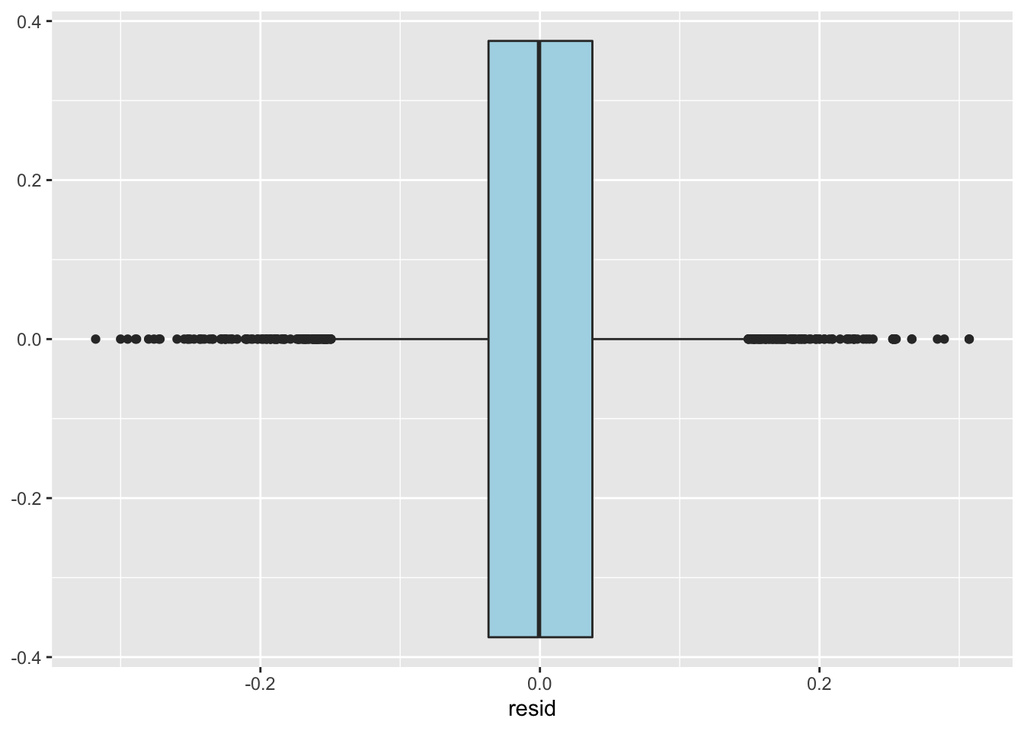

```r
resid %>% as.data.frame() %>% ggplot(aes(x=resid)) + geom_boxplot(fill="lightblue")
```

Previous tools (3-sigma, IQR) were based on univariate information

Multivariate information is better to detect outliers, but more difficult:

- Based on regression (target-based outliers)
- Based on multivariate tools (clustering, Mahalanobis distance, etc.)
- Based on dimensionality reduction (PCA)

Let’s use the package outliers to detect municipalities with participation anomalies (respect to unemployment):

```r
library(outliers)

idx = outlier(resid, logical=T)
# outlier
total.data[idx,]
```

```
##      CODIGOINE ccaa provincia municipio total_votos total_censo total_part
## 6340     42206   08        42       206           3           8      0.375
##                 CCAA Provincia            Municipio total_paro SUPERFICIE
## 6340 Castilla y León     Soria Villanueva de Gormaz          0   2143.082
##      ALTITUD LONGITUD_ETRS89 LATITUD_ETRS89 EDAD_MEDIA de0.18 de19.67 masde68
## 6340     965       -3.062374       41.46782   64.57143      0       4       3
##      de0.12 HOMBRES MUJERES habitantes  densidad sexratio jovenes   seniors
## 6340      0       5       2          7 0.1512093      2.5       0 0.4285714
##      paro
## 6340    0
```

No unemployment but 37% election participation

**Discretize age**

```r
# Create the column young, and indicate whether town is young or not
total.data$EdadG[total.data$jovenes > .17] <- 'Young'
total.data$EdadG[total.data$jovenes <= .17] <- 'Senior'
total.data$EdadG = factor(total.data$EdadG)

# Show counts
prop.table(table(total.data$EdadG))
```

```
##
##    Senior     Young
## 0.7403941 0.2596059
```

**Discretize unemployment**

```r
total.data$paroD[total.data$paro <= 0.05] <- 'bajo'
total.data$paroD[total.data$paro <= 0.10 & total.data$paro > .05] <- 'medio'
total.data$paroD[total.data$paro > 0.10] <- 'alto'

total.data$paroD = factor(total.data$paroD)

prop.table(table(total.data$paroD))
```

```
##
##       alto       bajo      medio
## 0.05517241 0.56834975 0.37647783
```

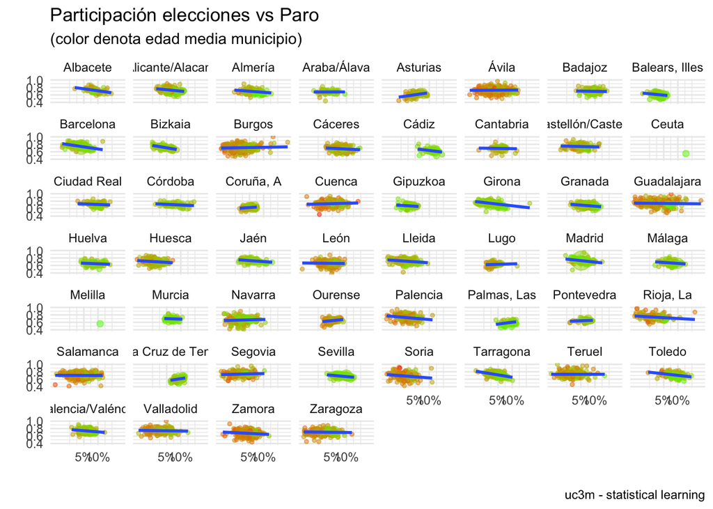

```r
ggplot(filter(total.data,paro>0), aes(paro, total_part, group=Provincia, size=habitantes, color=EDAD_MEDIA)) + scale_x_sqrt(breaks=c(0.05,0.1), label=c("5%","10%"))+
  geom_point(alpha=0.5) + geom_smooth(method=lm,se=F) +
  facet_wrap(~ Provincia) +
  scale_color_gradient(low="green", high="red") +
  theme_minimal()+ theme(legend.position="none") +
  labs(title = "Participación elecciones vs Paro", subtitle="(color denota edad media municipio)",caption="uc3m - statistical learning",
       x = "", y = "")
```

## Just another break

Let’s map some variables. To do that, we need the boundaries (polygons) for the municipalities. We can download the polygons in the shapefile (SHP) format from http://opendata.esri.es/datasets/municipios-ign

```r
municipios <- readOGR("data/Municipios_IGN/Municipios_IGN.shp")
```

```r
WGS84 <- CRS("+proj=longlat +ellps=WGS84 +datum=WGS84 +no_defs")
municipios <- spTransform(municipios,CRSobj=WGS84)

datos.mapa <- merge(municipios,total.data,by="CODIGOINE")
```

Now we can plot for instance our main variable: participation

```r
pal <- colorQuantile("Blues", datos.mapa$total_part, na.color="white")

datos.mapa %>% leaflet() %>%
  addProviderTiles(providers$CartoDB.Positron) %>%
 # addTiles("MapBox") %>%
  setView(lng=-3.69, lat=40.42, zoom = 9) %>%
  addPolygons(fillColor = ~ pal(total_part),fillOpacity = 0.6,color = "white",weight = .5, label = ~ paste0(datos.mapa$Municipio," ", round(total_part*100,2),"%"))
```

Or we can plot the unemployment rate in the same way

```r
pal <- colorQuantile("Greens", datos.mapa$paro, na.color="white")
# pal <- colorFactor(palette = 'Greens', domain = datos.mapa$paroD, na.color="white")

datos.mapa %>% leaflet() %>%
  addProviderTiles(providers$CartoDB.Positron) %>%
 # addTiles("MapBox") %>%
  setView(lng=-3.69, lat=40.42, zoom = 9) %>%
  addPolygons(fillColor = ~ pal(paro),fillOpacity = 0.6,color = "white",weight = .5, label = ~ paste0(datos.mapa$Municipio," ", round(paro*100,2),"%"))
```

España vacía

```r
total.data$habitantesD[total.data$habitantes <= 5000] <- 'pocos'
total.data$habitantesD[total.data$habitantes > 5000] <- 'muchos'
total.data$habitantesD = as.factor(total.data$habitantesD)

datos.mapa.empty <- merge(municipios,filter(total.data, habitantes<5000),by="CODIGOINE")

pal <- colorFactor(
  palette = c('white', 'skyblue2'),
  domain = datos.mapa.empty$habitantesD,na.color="white"
)

# datos.mapa.empty %>% leaflet() %>%
#   addProviderTiles(providers$CartoDB.Positron) %>%
#  # addTiles("MapBox") %>%
#   setView(lng=-3.69, lat=40.42, zoom = 6) %>%
#   addPolygons(fillColor = ~ pal(habitantesD),weight = .5,fillOpacity = 0.8,color = "white", label = ~ paste0(datos.mapa.empty$Municipio," ", habitantes," hab"))
```

Empty Spain in blue

46.6M hab total

12% of Spanish population live there

## Last data source

Let’s try to get now the income (per capita)

Only for municipalities with more than 1000 inhabitants

No Navarra, No País Vasco: “País Vasco y Navarra que quedan fuera del ámbito territorial del impuesto”

```r
renta=htmltab("https://www.agenciatributaria.es/AEAT/Contenidos_Comunes/La_Agencia_Tributaria/Estadisticas/Publicaciones/sites/irpfmunicipios/2018/jrubik7fe28e5d4daeab97eaf47efe29f0716914ab405e.html")
# write.csv(renta, file="data/renta2018.csv", row.names=F)
# renta = read.csv(file="data/renta2018.csv")
renta = renta %>% drop_na()
```

Feature extraction:

```r
renta = renta %>% select(c(1,4,7))
renta$V1 = str_extract(renta$V1, "[0-9]+")
colnames(renta)=c("CODIGOINE", "habitantes2", "renta")
renta$habitantes2 = as.numeric(gsub(".","", renta$habitantes2, fixed=T))
renta$renta = as.numeric(gsub(".","", renta$renta, fixed=T))
```

Merge:

```r
# CODIGOINE must be in the same format (char) and with same numbers
renta$CODIGOINE=factor(str_pad(renta$CODIGOINE, 5, pad = "0"))
total.data=merge(total.data, renta, by="CODIGOINE", all.x=T)
sum(is.na(total.data$renta))
```

```
## [1] 5234
```

**Missing values: advanced approaches**

Some advanced approaches:

```
- Simple imputation (use the mean for non-NAs, or the median, mode, etc.)
- Regressions: train with non-NAs to predict NAs
- k-nearest neighbour (kNN) imputation
- Multiple imputation: for each NA, multiple imputations are found to capture better sample variability, and then a pooling approach is performed to have the final imputation
```

**Imputation by the median**

```r
total.data$renta_imp_median = total.data$renta
total.data$renta_imp_median[is.na(total.data$renta)] = median(total.data$renta, na.rm=T)
```

Is it a good method in our case?

The same, but grouping by provincia

```r
total.data = total.data %>% group_by(provincia) %>%
mutate(renta_imp_provincia=ifelse(is.na(renta),median(renta,na.rm=TRUE),renta))
```

Take care: still NAs in País Vasco and Navarra

**Imputation by regression**

First, train a model with non-NAs:

```r
i.na = is.na(total.data$renta)
renta.model <- lm(renta ~ paro + EDAD_MEDIA + densidad + total_part, data = total.data[!i.na,])
summary(renta.model)
```

```
##
## Call:
## lm(formula = renta ~ paro + EDAD_MEDIA + densidad + total_part,
##     data = total.data[!i.na, ])
##
## Residuals:
##    Min     1Q Median     3Q    Max
## -23189  -2564   -166   2170 188997
##
## Coefficients:
##               Estimate Std. Error t value Pr(>|t|)
## (Intercept)  4.877e+04  2.070e+03   23.57  < 2e-16 ***
## paro        -1.039e+05  4.639e+03  -22.39  < 2e-16 ***
## EDAD_MEDIA  -5.956e+02  2.487e+01  -23.95  < 2e-16 ***
## densidad     2.310e+00  1.866e-01   12.37  < 2e-16 ***
## total_part   8.991e+03  1.963e+03    4.58 4.85e-06 ***
## ---
## Signif. codes:  0 '***' 0.001 '**' 0.01 '*' 0.05 '.' 0.1 ' ' 1
##
## Residual standard error: 5737 on 2881 degrees of freedom
## Multiple R-squared:  0.3108, Adjusted R-squared:  0.3099
## F-statistic: 324.8 on 4 and 2881 DF,  p-value: < 2.2e-16
```

Then, predict the NAs:

```r
total.data$renta_imp_reg = total.data$renta
total.data$renta_imp_reg[i.na]=predict(renta.model, newdata = total.data[i.na,])
```

Valid if $R^2$ is relatively high, not the case

**Multiple imputation**

For each NA, multiple imputations are found to capture better sample variability, and then a pooling approach is performed to have the final imputation

MICE (Multivariate Imputation via Chained Equations): widely used

With mice, each variable has its own imputation method (for continuous variables, binary, categorical, etc.)

```r
mice.obj=mice(total.data[,c(2,3,7,16,24,25,26,27,28,33)], method = 'rf')
mice.obj.imp=mice::complete(mice.obj)
total.data$renta_imp_mice = mice.obj.imp$renta
```

Sort income

```r
total.data %>% arrange(desc(renta)) %>% select(Municipio, Provincia, renta, EdadG, paroD) %>% head(10)
```

```
## # A tibble: 10 x 6
## # Groups:   provincia [2]
##    provincia Municipio               Provincia  renta EdadG paroD
##    <fct>     <chr>                   <chr>      <dbl> <fct> <fct>
##  1 08        Matadepera              Barcelona 218788 Young bajo
##  2 28        Pozuelo de Alarcón      Madrid     79506 Young bajo
##  3 28        Boadilla del Monte      Madrid     61910 Young bajo
##  4 28        Alcobendas              Madrid     60842 Young bajo
##  5 08        Sant Just Desvern       Barcelona  58875 Young bajo
##  6 08        Sant Cugat del Vallès   Barcelona  57565 Young bajo
##  7 28        Majadahonda             Madrid     54506 Young bajo
##  8 08        Alella                  Barcelona  54412 Young bajo
##  9 28        Torrelodones            Madrid     54123 Young bajo
## 10 28        Villanueva de la Cañada Madrid     52826 Young bajo
```

```r
total.data %>% arrange(desc(renta_imp_mice)) %>% select(Municipio, Provincia, renta, renta_imp_mice, EdadG, paroD, habitantes) %>% head(10)
```

```
## # A tibble: 10 x 8
## # Groups:   provincia [3]
##    provincia Municipio    Provincia  renta renta_imp_mice EdadG paroD habitantes
##    <fct>     <chr>        <chr>      <dbl>          <dbl> <fct> <fct>      <int>
##  1 08        Matadepera   Barcelona 218788         218788 Young bajo        9186
##  2 08        Montmaneu    Barcelona     NA         218788 Seni… bajo         153
##  3 17        Sant Feliu … Girona        NA         218788 Seni… medio        825
##  4 28        Pozuelo de … Madrid     79506          79506 Young bajo       85605
##  5 28        Boadilla de… Madrid     61910          61910 Young bajo       51463
##  6 28        Alcobendas   Madrid     60842          60842 Young bajo      114864
##  7 28        Somosierra   Madrid        NA          60842 Seni… bajo          77
##  8 08        Sant Just D… Barcelona  58875          58875 Young bajo       17201
##  9 08        Gallifa      Barcelona     NA          57565 Seni… bajo         180
## 10 08        Sant Cugat … Barcelona  57565          57565 Young bajo       89516
```

**Analyze income in Spain**

With incomplete information about income:

```r
data.map = merge(municipios,total.data,by="CODIGOINE")

pal <- colorQuantile("Blues", data.map$renta, na.color="white")

data.map     %>% leaflet() %>%
  addProviderTiles(providers$CartoDB.Positron) %>%
  setView(lng=-3.69, lat=40.42, zoom = 9) %>%
  addPolygons(fillColor = ~ pal(renta),opacity = 0.2,fillOpacity = 0.6,color = "white",weight = .5, label = ~ paste0(Municipio,": ", renta))
```

With complete information:

```r
pal <- colorQuantile("Blues", data.map$renta_imp_mice, na.color="white")

data.map     %>% leaflet() %>%
  addProviderTiles(providers$CartoDB.Positron) %>%
  setView(lng=-3.69, lat=40.42, zoom = 9) %>%
  addPolygons(fillColor = ~ pal(renta_imp_mice),opacity = 0.2,fillOpacity = 0.6,color = "white",weight = .5, label = ~ paste0(Municipio,": ", renta_imp_mice))
```

## Analyze Participation

Plot the relation between Participation and Income (at province level):

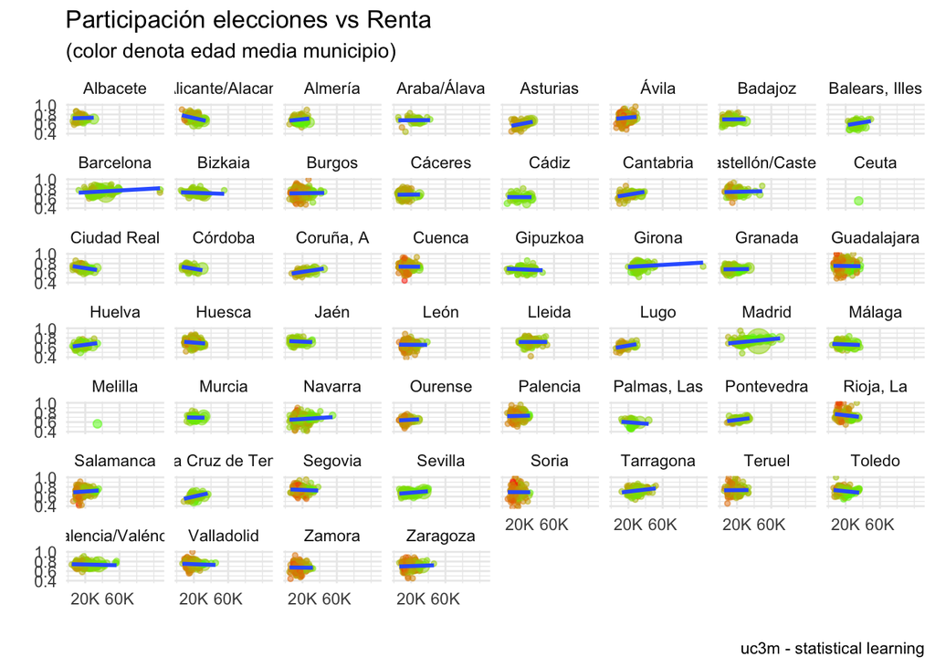

```r
total.data %>% filter(renta_imp_mice>10000) %>%
ggplot(aes(x=renta_imp_mice, y=total_part, group=Provincia, size=habitantes, color=EDAD_MEDIA)) +
  scale_x_log10(breaks=c(20000,60000), label=c("20K","60K"))+
  geom_point(alpha=0.5) + geom_smooth(method=lm,se=F) +
  facet_wrap(~ Provincia) +
  scale_color_gradient(low="green", high="red") +
  theme_minimal()+ theme(legend.position="none") +
  labs(title = "Participación elecciones vs Renta", subtitle="(color denota edad media municipio)", caption="uc3m - statistical learning",
       x = "", y = "")
```

Let’s make some regression models to understand better the relations:

```r
lm(total_part ~ Provincia, total.data) %>% summary()
```

```
##
## Call:
## lm(formula = total_part ~ Provincia, data = total.data)
##
## Residuals:
##      Min       1Q   Median       3Q      Max
## -0.31789 -0.03679 -0.00065  0.03751  0.30711
##
## Coefficients:
##                                   Estimate Std. Error t value Pr(>|t|)
## (Intercept)                      0.7243516  0.0068687 105.456  < 2e-16 ***
## ProvinciaAlicante/Alacant        0.0030709  0.0087344   0.352 0.725163
## ProvinciaAlmería                -0.0325388  0.0093290  -3.488 0.000489 ***
## ProvinciaAraba/Álava            -0.0450638  0.0112988  -3.988 6.71e-05 ***
## ProvinciaAsturias               -0.1181209  0.0099902 -11.824  < 2e-16 ***
## ProvinciaÁvila                   0.0040299  0.0079831   0.505 0.613717
## ProvinciaBadajoz                -0.0264992  0.0084886  -3.122 0.001804 **
## ProvinciaBalears, Illes         -0.1154608  0.0104136 -11.088  < 2e-16 ***
## ProvinciaBarcelona               0.0189402  0.0077703   2.438 0.014810 *
## ProvinciaBizkaia                -0.0058453  0.0091558  -0.638 0.523212
## ProvinciaBurgos                 -0.0136359  0.0076317  -1.787 0.074018 .
## ProvinciaCáceres                -0.0433224  0.0081036  -5.346 9.24e-08 ***
## ProvinciaCádiz                  -0.0942024  0.0118519  -7.948 2.15e-15 ***
## ProvinciaCantabria              -0.0348860  0.0093499  -3.731 0.000192 ***
## ProvinciaCastellón/Castelló      0.0156534  0.0088082   1.777 0.075583 .
## ProvinciaCeuta                  -0.1736662  0.0644346  -2.695 0.007049 **
## ProvinciaCiudad Real            -0.0108297  0.0093499  -1.158 0.246791
## ProvinciaCórdoba                -0.0178441  0.0100950  -1.768 0.077161 .
## ProvinciaCoruña, A              -0.0966988  0.0095559 -10.119  < 2e-16 ***
## ProvinciaCuenca                  0.0094914  0.0080266   1.182 0.237042
## ProvinciaGipuzkoa               -0.0499169  0.0096862  -5.153 2.62e-07 ***
## ProvinciaGirona                  0.0168127  0.0081088   2.073 0.038168 *
## ProvinciaGranada                -0.0448824  0.0084288  -5.325 1.04e-07 ***
## ProvinciaGuadalajara             0.0231070  0.0078379   2.948 0.003206 **
## ProvinciaHuelva                 -0.0752028  0.0099568  -7.553 4.72e-14 ***
## ProvinciaHuesca                 -0.0215322  0.0082158  -2.621 0.008788 **
## ProvinciaJaén                    0.0044810  0.0094602   0.474 0.635751
## ProvinciaLeón                   -0.0658761  0.0081629  -8.070 8.03e-16 ***
## ProvinciaLleida                 -0.0083332  0.0080591  -1.034 0.301161
## ProvinciaLugo                   -0.0969335  0.0104136  -9.308  < 2e-16 ***
```

[output cut: 13 more lines]

```
## ProvinciaSevilla                -0.0446003  0.0092882  -4.802 1.60e-06 ***
## ProvinciaSoria                  -0.0314622  0.0083432  -3.771 0.000164 ***
## ProvinciaTarragona               0.0011675  0.0083359   0.140 0.888618
## ProvinciaTeruel                  0.0095697  0.0080357   1.191 0.233727
## ProvinciaToledo                 -0.0087561  0.0082037  -1.067 0.285850
## ProvinciaValencia/Valéncia       0.0126099  0.0079164   1.593 0.111225
## ProvinciaValladolid              0.0208043  0.0080884   2.572 0.010126 *
## ProvinciaZamora                 -0.0503100  0.0079831  -6.302 3.09e-10 ***
## ProvinciaZaragoza               -0.0193894  0.0078223  -2.479 0.013206 *
## ---
## Signif. codes:  0 '***' 0.001 '**' 0.01 '*' 0.05 '.' 0.1 ' ' 1
##
## Residual standard error: 0.06407 on 8068 degrees of freedom
## Multiple R-squared:  0.2287, Adjusted R-squared:  0.2238
## F-statistic:  46.9 on 51 and 8068 DF,  p-value: < 2.2e-16
```

```r
lm(total_part ~ Provincia + log(paro+1)*log(renta_imp_mice)+poly(EDAD_MEDIA,2), total.data) %>% summary()
```

```
##
## Call:
## lm(formula = total_part ~ Provincia + log(paro + 1) * log(renta_imp_mice) +
##     poly(EDAD_MEDIA, 2), data = total.data)
##
## Residuals:
##      Min       1Q   Median       3Q      Max
## -0.31582 -0.03531  0.00067  0.03629  0.33073
##
## Coefficients:
##                                    Estimate Std. Error t value Pr(>|t|)
## (Intercept)                        0.274605   0.078201   3.512 0.000448 ***
## ProvinciaAlicante/Alacant         -0.002582   0.008735  -0.296 0.767541
## ProvinciaAlmería                  -0.036728   0.009293  -3.952 7.81e-05 ***
## ProvinciaAraba/Álava              -0.062624   0.011383  -5.501 3.89e-08 ***
## ProvinciaAsturias                 -0.134594   0.010087 -13.344  < 2e-16 ***
## ProvinciaÁvila                    -0.009273   0.008094  -1.146 0.251990
## ProvinciaBadajoz                  -0.023037   0.008417  -2.737 0.006215 **
## ProvinciaBalears, Illes           -0.136994   0.010701 -12.802  < 2e-16 ***
## ProvinciaBarcelona                -0.001983   0.008227  -0.241 0.809576
## ProvinciaBizkaia                  -0.021496   0.009293  -2.313 0.020741 *
## ProvinciaBurgos                   -0.032759   0.007854  -4.171 3.07e-05 ***
## ProvinciaCáceres                  -0.046248   0.008020  -5.766 8.39e-09 ***
## ProvinciaCádiz                    -0.078352   0.011828  -6.624 3.71e-11 ***
## ProvinciaCantabria                -0.046651   0.009401  -4.962 7.11e-07 ***
## ProvinciaCastellón/Castelló        0.002688   0.008854   0.304 0.761477
## ProvinciaCeuta                    -0.129492   0.064109  -2.020 0.043430 *
## ProvinciaCiudad Real              -0.007800   0.009252  -0.843 0.399171
## ProvinciaCórdoba                  -0.016494   0.010029  -1.645 0.100070
## ProvinciaCoruña, A                -0.112405   0.009627 -11.676  < 2e-16 ***
## ProvinciaCuenca                   -0.002179   0.008083  -0.270 0.787467
## ProvinciaGipuzkoa                 -0.066668   0.009902  -6.732 1.78e-11 ***
## ProvinciaGirona                   -0.008474   0.008535  -0.993 0.320824
## ProvinciaGranada                  -0.042651   0.008400  -5.078 3.91e-07 ***
## ProvinciaGuadalajara               0.007900   0.007996   0.988 0.323235
## ProvinciaHuelva                   -0.069705   0.009882  -7.054 1.89e-12 ***
## ProvinciaHuesca                   -0.046815   0.008488  -5.515 3.59e-08 ***
## ProvinciaJaén                      0.002213   0.009500   0.233 0.815824
## ProvinciaLeón                     -0.081810   0.008281  -9.879  < 2e-16 ***
## ProvinciaLleida                   -0.039285   0.008475  -4.635 3.62e-06 ***
```

[output cut: 19 more lines]

```
## ProvinciaValencia/Valéncia         0.006250   0.007997   0.782 0.434486
## ProvinciaValladolid                0.003128   0.008239   0.380 0.704213
## ProvinciaZamora                   -0.063194   0.008091  -7.811 6.41e-15 ***
## ProvinciaZaragoza                 -0.041057   0.008052  -5.099 3.50e-07 ***
## log(paro + 1)                      4.694826   1.488182   3.155 0.001612 **
## log(renta_imp_mice)                0.048519   0.007871   6.164 7.41e-10 ***
## poly(EDAD_MEDIA, 2)1               0.334991   0.100681   3.327 0.000881 ***
## poly(EDAD_MEDIA, 2)2              -0.446964   0.069569  -6.425 1.40e-10 ***
## log(paro + 1):log(renta_imp_mice) -0.512479   0.151146  -3.391 0.000701 ***
## ---
## Signif. codes:  0 '***' 0.001 '**' 0.01 '*' 0.05 '.' 0.1 ' ' 1
##
## Residual standard error: 0.06334 on 8063 degrees of freedom
## Multiple R-squared:  0.2466, Adjusted R-squared:  0.2414
## F-statistic: 47.12 on 56 and 8063 DF,  p-value: < 2.2e-16
```

```r
cor(log(total.data$renta_imp_mice),log(total.data$paro+1))
```

```
## [1] -0.09953948
```

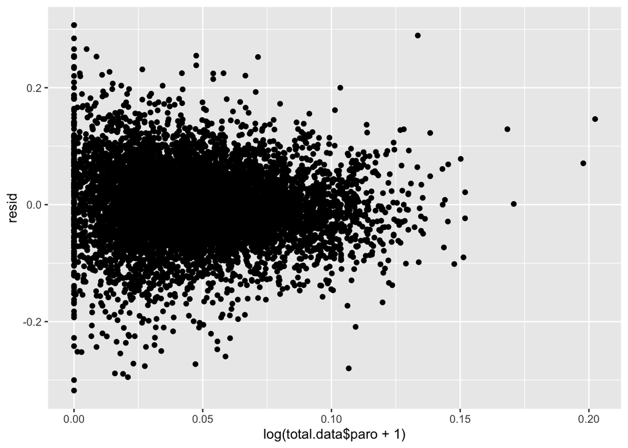

```r
lm.fit = lm(total_part ~ Provincia, total.data)
resid = residuals(lm.fit)
qplot(log(total.data$paro+1), resid)
```

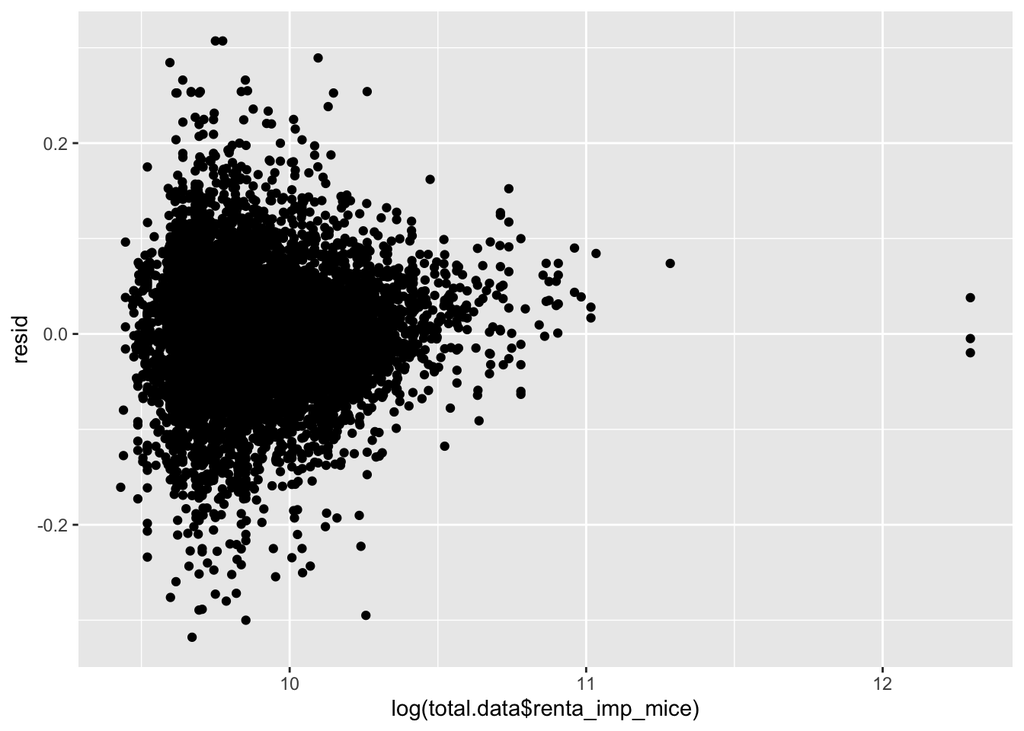

```r
qplot(log(total.data$renta_imp_mice), resid)
```

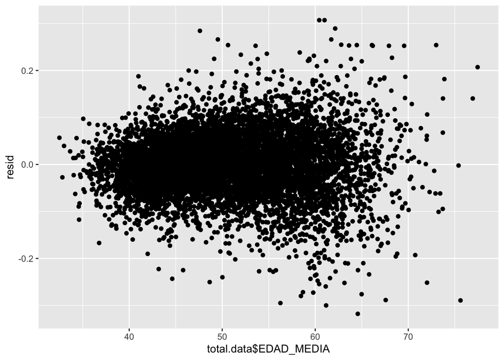

```r
qplot(total.data$EDAD_MEDIA, resid)
```

Relations, besides Provincia, are weak

## Scale

For some models, it is required when features have different ranges

The models can then equally weight each feature. Otherwise a feature measured in meters will have more weight than the same feature in km

The disadvantage is that we lose variability information

We can either standardize (remove the mean and divide by the standard deviation) or normalize

1. Normalization:

```r
total.data$rentaNormalized <- (total.data$renta_imp_mice - min(total.data$renta_imp_mice))/(max(total.data$renta_imp_mice) - min(total.data$renta_imp_mice))
summary(total.data$rentaNormalized)
```

```
##    Min. 1st Qu.  Median    Mean 3rd Qu.    Max.
## 0.00000 0.02062 0.03187 0.03923 0.05093 1.00000
```

2. Standardization

```r
total.data$rentaNormalized <- scale(total.data$renta_imp_mice)
summary(total.data$rentaNormalized)
```

```
##        V1
##  Min.   :-1.2432
##  1st Qu.:-0.5898
##  Median :-0.2334
##  Mean   : 0.0000
##  3rd Qu.: 0.3706
##  Max.   :30.4450
```

**Scale effect:**

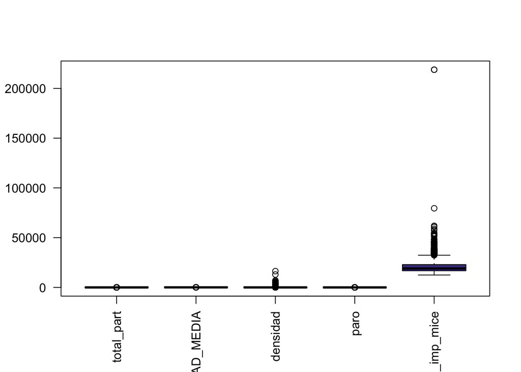

```r
boxplot(total.data[,c("total_part", "EDAD_MEDIA", "densidad", "paro", "renta_imp_mice")], las = 2, cex.max = 0.8, col = "darkslateblue")
```

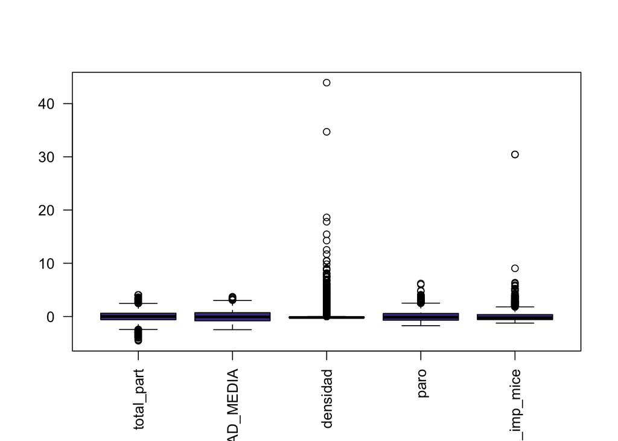

```r
boxplot(scale(total.data[,c("total_part", "EDAD_MEDIA", "densidad", "paro", "renta_imp_mice")]), las = 2, cex.max = 0.8, col = "darkslateblue")
```

Note variances are the same (=1)

## Encoding

Most statistical and machine-learning models require the predictors to be in some sort of numeric encoding to be used. For example, linear regression required numbers so that it can assign slopes to each of the predictors.

The most common encoding is to make simple dummy variables: if we have a predictor with $c$ levels, then $c-1$ dummies are needed. In this way, the $X$ matrix is full rank.

```r
lm(total_part ~ Provincia + log(paro+1) + log(renta_imp_mice)+poly(EDAD_MEDIA,2), total.data) %>% summary()
```

```
##
## Call:
## lm(formula = total_part ~ Provincia + log(paro + 1) + log(renta_imp_mice) +
##     poly(EDAD_MEDIA, 2), data = total.data)
##
## Residuals:
##      Min       1Q   Median       3Q      Max
## -0.31841 -0.03549  0.00043  0.03632  0.31923
##
## Coefficients:
##                                   Estimate Std. Error t value Pr(>|t|)
## (Intercept)                      0.4888409  0.0461070  10.602  < 2e-16 ***
## ProvinciaAlicante/Alacant       -0.0052389  0.0087051  -0.602 0.547312
## ProvinciaAlmería                -0.0383987  0.0092856  -4.135 3.58e-05 ***
## ProvinciaAraba/Álava            -0.0644229  0.0113785  -5.662 1.55e-08 ***
## ProvinciaAsturias               -0.1384735  0.0100279 -13.809  < 2e-16 ***
## ProvinciaÁvila                  -0.0115617  0.0080712  -1.432 0.152052
## ProvinciaBadajoz                -0.0219900  0.0084169  -2.613 0.009002 **
## ProvinciaBalears, Illes         -0.1369776  0.0107080 -12.792  < 2e-16 ***
## ProvinciaBarcelona              -0.0031002  0.0082261  -0.377 0.706275
## ProvinciaBizkaia                -0.0234389  0.0092815  -2.525 0.011578 *
## ProvinciaBurgos                 -0.0351958  0.0078263  -4.497 6.98e-06 ***
## ProvinciaCáceres                -0.0461523  0.0080252  -5.751 9.20e-09 ***
## ProvinciaCádiz                  -0.0811643  0.0118062  -6.875 6.67e-12 ***
## ProvinciaCantabria              -0.0496622  0.0093653  -5.303 1.17e-07 ***
## ProvinciaCastellón/Castelló      0.0003057  0.0088316   0.035 0.972385
## ProvinciaCeuta                  -0.1508615  0.0638400  -2.363 0.018145 *
## ProvinciaCiudad Real            -0.0084286  0.0092557  -0.911 0.362509
## ProvinciaCórdoba                -0.0176548  0.0100292  -1.760 0.078388 .
## ProvinciaCoruña, A              -0.1154648  0.0095912 -12.039  < 2e-16 ***
## ProvinciaCuenca                 -0.0043171  0.0080635  -0.535 0.592399
## ProvinciaGipuzkoa               -0.0675818  0.0099052  -6.823 9.57e-12 ***
## ProvinciaGirona                 -0.0083649  0.0085403  -0.979 0.327382
## ProvinciaGranada                -0.0438041  0.0083984  -5.216 1.88e-07 ***
## ProvinciaGuadalajara             0.0056464  0.0079740   0.708 0.478900
## ProvinciaHuelva                 -0.0708089  0.0098830  -7.165 8.48e-13 ***
## ProvinciaHuesca                 -0.0485951  0.0084777  -5.732 1.03e-08 ***
## ProvinciaJaén                    0.0005705  0.0094936   0.060 0.952086
## ProvinciaLeón                   -0.0846706  0.0082433 -10.271  < 2e-16 ***
## ProvinciaLleida                 -0.0387337  0.0084790  -4.568 4.99e-06 ***
```

[output cut: 18 more lines]

```
## ProvinciaToledo                 -0.0071226  0.0081391  -0.875 0.381540
## ProvinciaValencia/Valéncia       0.0034233  0.0079584   0.430 0.667100
## ProvinciaValladolid              0.0005418  0.0082089   0.066 0.947376
## ProvinciaZamora                 -0.0655437  0.0080663  -8.126 5.11e-16 ***
## ProvinciaZaragoza               -0.0429484  0.0080382  -5.343 9.39e-08 ***
## log(paro + 1)                   -0.3493178  0.0389580  -8.967  < 2e-16 ***
## log(renta_imp_mice)              0.0269654  0.0046442   5.806 6.63e-09 ***
## poly(EDAD_MEDIA, 2)1             0.3603087  0.1004695   3.586 0.000337 ***
## poly(EDAD_MEDIA, 2)2            -0.4964576  0.0680648  -7.294 3.30e-13 ***
## ---
## Signif. codes:  0 '***' 0.001 '**' 0.01 '*' 0.05 '.' 0.1 ' ' 1
##
## Residual standard error: 0.06338 on 8064 degrees of freedom
## Multiple R-squared:  0.2455, Adjusted R-squared:  0.2404
## F-statistic: 47.71 on 55 and 8064 DF,  p-value: < 2.2e-16
```

```r
# X matrix
X = model.matrix(~ Provincia + log(paro+1) + log(renta_imp_mice)+poly(EDAD_MEDIA,2), data=total.data)[,-1]  # skip column of ones, useful in lasso or ridge regression
# y variable
y = total.data$total_part
```

You need to encode (or use a factor variable) for instance: month of the year, day of the week, etc. **Why?**

## Conclusions

- Remember: feature engineering is the process of generating features (variables) useful as input for machine-learning tools. The better the input, the better the prediction.
- Feature extraction creates new features from original raw variables
- Do not confuse with feature selection: how to get a subset of the features
- Feature selection or variable selection is better understood in a regression context
- PCA can also be used for feature extraction
- You need to deal always with outliers and missing values